# Effects of Loan Properties on Borrower's APR

## by Ifeanyichukwu Obute

## Investigation Overview

In this investigation, I would like to discover what are the major loan features for predicting the borrower's annual percentage rate (APR) for the loan.. The main focus was on the stated monthly income, monthly loan payment, and the characteristics of the borrowers APR

## Dataset Overview

The studied data set contains 113,937 loans with 81 variables on each loan, including loan amount, borrower rate (or interest rate), current loan status, borrower income, and many others. provided by Prosper Marketplace, California-based pioneering company in the peer-to-peer lending industry in the U.S.

## Distribution of Borrower APR

The distribution of APR looks multimodal. A small peak centered at 0.1, a large peak centered at 0.2. There is also a small peak centered 0.3. Additionally, there is a very shape peak between 0.35 and 0.36. Only very few loans have APR greater than 0.43.

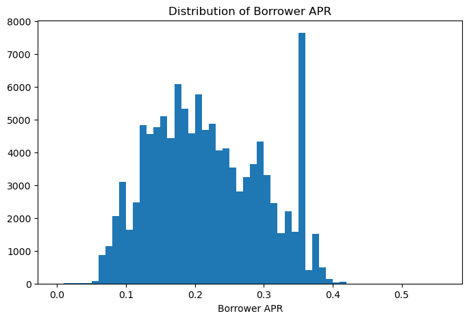

## Borrower APR vs. Monthly Loan Payment

At different size of the monthly loan payment, the APR has a large range, but the range of APR decrease with the increase of loan payment. Overall, the borrower APR decrease with increase of monthly loan payment

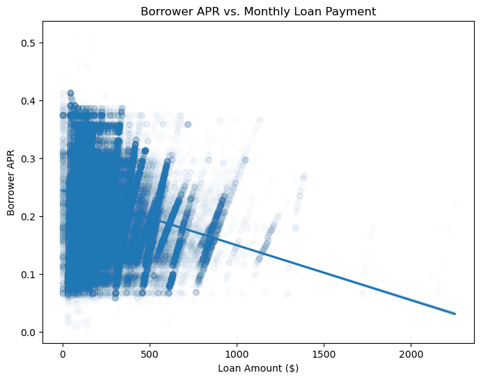

## Borrower APR vs. Prosper Rating

[figure not shown]